# RNAseq pipeline - Bioconductor

Ricardo Gonzalo Sanz y Alex Sánchez-Pla

13 de juny, 2020

## 1. Introduction

This document contains a RNA-seq case study based in a related workflow that can be found in Bioconductor’s web siate: http://master.bioconductor.org/packages/release/workflows/vignettes/rnaseqGene/inst/doc/rnaseqGene.html#aligning-reads-to-a-reference-genome.

The workflow follows the standard steps for RNAseq analysis as described in the figure below extracted from DOI: 10.1186/s12864-015-1876-7,

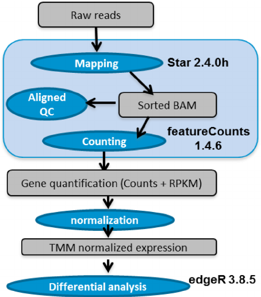

A A standard RNAseq workflow

AN important thing is to remember that it is relatively common not to go through all the workflow but, instead, start from the counts table resulting from the *gene quantification step*.

## 2. Data

THis use case relies on the data available in th e `airway` package. It consists of eight files with a small subset of the total number of reads in the experiment. We have selected a subset of reads because the full alignment files are large (a few gigabytes each), and because it takes between 10-30 minutes to count the fragments for each sample. We will use these files to demonstrate how a count matrix can be constructed from BAM files.

Reads from each sample are provided as .bam files.

```r
library("airway")
#to find out where on your computer the files from a package have been installed.
indir <- system.file("extdata", package="airway", mustWork=TRUE)
list.files(indir)
```

```
##  [1] "GSE52778_series_matrix.txt"        "Homo_sapiens.GRCh37.75_subset.gtf"
##  [3] "quants"                            "sample_table.csv"
##  [5] "SraRunInfo_SRP033351.csv"          "SRR1039508_subset.bam"
##  [7] "SRR1039509_subset.bam"             "SRR1039512_subset.bam"
##  [9] "SRR1039513_subset.bam"             "SRR1039516_subset.bam"
## [11] "SRR1039517_subset.bam"             "SRR1039520_subset.bam"
## [13] "SRR1039521_subset.bam"
```

Additionally a targets file is provided with informartion on groups and on sequencing process,

```r
#read the targets file of the experiment
csvfile <- file.path(indir, "sample_table.csv")
sampleTable <- read.csv(csvfile, row.names = 1)
sampleTable
```

```
##            SampleName    cell   dex albut        Run avgLength Experiment
## SRR1039508 GSM1275862  N61311 untrt untrt SRR1039508       126  SRX384345
## SRR1039509 GSM1275863  N61311   trt untrt SRR1039509       126  SRX384346
## SRR1039512 GSM1275866 N052611 untrt untrt SRR1039512       126  SRX384349
## SRR1039513 GSM1275867 N052611   trt untrt SRR1039513        87  SRX384350
## SRR1039516 GSM1275870 N080611 untrt untrt SRR1039516       120  SRX384353
## SRR1039517 GSM1275871 N080611   trt untrt SRR1039517       126  SRX384354
## SRR1039520 GSM1275874 N061011 untrt untrt SRR1039520       101  SRX384357
## SRR1039521 GSM1275875 N061011   trt untrt SRR1039521        98  SRX384358
##               Sample    BioSample
## SRR1039508 SRS508568 SAMN02422669
## SRR1039509 SRS508567 SAMN02422675
## SRR1039512 SRS508571 SAMN02422678
## SRR1039513 SRS508572 SAMN02422670
## SRR1039516 SRS508575 SAMN02422682
## SRR1039517 SRS508576 SAMN02422673
## SRR1039520 SRS508579 SAMN02422683
## SRR1039521 SRS508580 SAMN02422677
```

## 3. Workflow

Once the reads have been aligned, there are a number of tools that can be used to count the number of reads/fragments that can be assigned to genomic features for each sample. These often take as input a set of SAM/BAM alignment files and a file specifying the genomic features, e.g. a GFF3 or GTF file specifying the gene models.

### 3.1 DESeq2 import functions

The following tools can be used generate count matrices:

- `summarizeOverlaps` (Lawrence et al. 2013),
- `featureCounts` (Liao, Smyth, and Shi 2014),
- `tximport` (Soneson, Love, and Robinson 2015),
- `htseq-count` (Anders, Pyl, and Huber 2015).

Here we will proceed using : Using the column in the sample table, we construct the full paths to the files we want to perform the counting operation on:

```r
filenames <- file.path(indir, paste0(sampleTable$Run, "_subset.bam"))
file.exists(filenames)
```

```
## [1] TRUE TRUE TRUE TRUE TRUE TRUE TRUE TRUE
```

```r
filenames
```

```
## [1] "/home/alex/R/x86_64-pc-linux-gnu-library/4.0/airway/extdata/SRR1039508_subset.bam"
## [2] "/home/alex/R/x86_64-pc-linux-gnu-library/4.0/airway/extdata/SRR1039509_subset.bam"
## [3] "/home/alex/R/x86_64-pc-linux-gnu-library/4.0/airway/extdata/SRR1039512_subset.bam"
## [4] "/home/alex/R/x86_64-pc-linux-gnu-library/4.0/airway/extdata/SRR1039513_subset.bam"
## [5] "/home/alex/R/x86_64-pc-linux-gnu-library/4.0/airway/extdata/SRR1039516_subset.bam"
## [6] "/home/alex/R/x86_64-pc-linux-gnu-library/4.0/airway/extdata/SRR1039517_subset.bam"
## [7] "/home/alex/R/x86_64-pc-linux-gnu-library/4.0/airway/extdata/SRR1039520_subset.bam"
## [8] "/home/alex/R/x86_64-pc-linux-gnu-library/4.0/airway/extdata/SRR1039521_subset.bam"
```

We indicate in Bioconductor that these files are BAM files using the BamFileList function from the that provides an R interface to BAM files. Here we also specify details about how the BAM files should be treated, e.g., only process 2 million reads at a time.

```r
library("Rsamtools")
bamfiles <- BamFileList(filenames, yieldSize=2000000)
```

We can check the chromosome names (here called “seqnames”) in the alignment files like so:

```r
seqinfo(bamfiles[1])
```

```
## Seqinfo object with 84 sequences from an unspecified genome:
##   seqnames   seqlengths isCircular genome
##   1           249250621       <NA>   <NA>
##   10          135534747       <NA>   <NA>
##   11          135006516       <NA>   <NA>
##   12          133851895       <NA>   <NA>
##   13          115169878       <NA>   <NA>
##   ...               ...        ...    ...
##   GL000210.1      27682       <NA>   <NA>
##   GL000231.1      27386       <NA>   <NA>
##   GL000229.1      19913       <NA>   <NA>
##   GL000226.1      15008       <NA>   <NA>
##   GL000207.1       4262       <NA>   <NA>
```

### 3.2 Defining gene models

Next, we need to read in the gene model that will be used for counting reads/fragments. We will read the gene model from an Ensembl GTF file (Flicek et al. 2014), using makeTxDbFromGFF from the GenomicFeatures package. GTF files can be downloaded from Ensembl’s FTP site or other gene model repositories. A TxDb object is a database that can be used to generate a variety of range-based objects, such as exons, transcripts, and genes. We want to make a list of exons grouped by gene for counting read/fragments. \ Here we will demonstrate loading from a GTF file, we indicate that none of our sequences (chromosomes) are circular using a 0-length character vector.

```r
library("GenomicFeatures")

gtffile <- file.path(indir,"Homo_sapiens.GRCh37.75_subset.gtf")
txdb <- makeTxDbFromGFF(gtffile, format = "gtf", circ_seqs = character())
txdb
```

```
## TxDb object:
## # Db type: TxDb
## # Supporting package: GenomicFeatures
## # Data source: /home/alex/R/x86_64-pc-linux-gnu-library/4.0/airway/extdata/Homo_sapiens.GRCh37.75_subset.gtf
## # Organism: NA
## # Taxonomy ID: NA
## # miRBase build ID: NA
## # Genome: NA
## # Nb of transcripts: 65
## # Db created by: GenomicFeatures package from Bioconductor
## # Creation time: 2020-06-13 20:18:47 +0200 (Sat, 13 Jun 2020)
## # GenomicFeatures version at creation time: 1.40.0
## # RSQLite version at creation time: 2.2.0
## # DBSCHEMAVERSION: 1.2
```

The following line produces a GRangesList of all the exons grouped by gene (Lawrence et al. 2013). Each element of the list is a GRanges object of the exons for a gene.

```r
ebg <- exonsBy(txdb, by="gene")
ebg
```

```
## GRangesList object of length 20:
## $ENSG00000009724
## GRanges object with 18 ranges and 2 metadata columns:
##        seqnames            ranges strand |   exon_id       exon_name
##           <Rle>         <IRanges>  <Rle> | <integer>     <character>
##    [1]        1 11086580-11087705      - |        98 ENSE00000818830
##    [2]        1 11090233-11090307      - |        99 ENSE00000472123
##    [3]        1 11090805-11090939      - |       100 ENSE00000743084
##    [4]        1 11094885-11094963      - |       101 ENSE00000743085
##    [5]        1 11097750-11097868      - |       102 ENSE00003482788
##    ...      ...               ...    ... .       ...             ...
##   [14]        1 11106948-11107176      - |       111 ENSE00003467404
##   [15]        1 11106948-11107176      - |       112 ENSE00003489217
##   [16]        1 11107260-11107280      - |       113 ENSE00001833377
##   [17]        1 11107260-11107284      - |       114 ENSE00001472289
##   [18]        1 11107260-11107290      - |       115 ENSE00001881401
##   -------
##   seqinfo: 1 sequence from an unspecified genome; no seqlengths
##
## ...
## <19 more elements>
```

### 3.3 Read counting step

The function `summarizeOverlaps` from the `GenomicAlignments` package will perform the counting step. This produces a SummarizedExperiment object that contains a variety of information about the experiment, and will be described in more detail below.

Here we specify to use one core, not multiple cores. We could have also skipped this line and the counting step would run in serial.

```r
library("GenomicAlignments")
library("BiocParallel")

register(SerialParam())
```

The following call creates the SummarizedExperiment object with counts:

```r
se <- summarizeOverlaps(features=ebg, reads=bamfiles,
                        mode="Union",
                        singleEnd=FALSE,
                        ignore.strand=TRUE,
                        fragments=TRUE )
```

We specify a number of arguments besides the features and the reads. The mode argument describes what kind of read overlaps will be counted. These modes are shown in Figure 1 of the Counting reads with summarizeOverlaps vignette for the GenomicAlignments package. Note that fragments will be counted only once to each gene, even if they overlap multiple exons of a gene which may themselves be overlapping. Setting singleEnd to FALSE indicates that the experiment produced paired-end reads, and we want to count a pair of reads (a fragment) only once toward the count for a gene. The fragments argument can be used when singleEnd=FALSE to specify if unpaired reads should be counted (yes if fragments=TRUE).

In order to produce correct counts, it is important to know if the RNA-seq experiment was strand-specific or not. This experiment was not strand-specific so we set ignore.strand to TRUE. However, certain strand-specific protocols could have the reads align only to the opposite strand of the genes. The user must check if the experiment was strand-specific and if so, whether the reads should align to the forward or reverse strand of the genes. For various counting/quantifying tools, one specifies counting on the forward or reverse strand in different ways, although this task is currently easiest with htseq-count, featureCounts, or the transcript abundance quantifiers mentioned previously. It is always a good idea to check the column sums of the count matrix (see below) to make sure these totals match the expected of the number of reads or fragments aligning to genes. Additionally, one can visually check the read alignments using a genome visualization tool.

### 3.4 SummarizedExperiment

```r
se
```

```
## class: RangedSummarizedExperiment
## dim: 20 8
## metadata(0):
## assays(1): counts
## rownames(20): ENSG00000009724 ENSG00000116649 ... ENSG00000271794
##   ENSG00000271895
## rowData names(0):
## colnames(8): SRR1039508_subset.bam SRR1039509_subset.bam ...
##   SRR1039520_subset.bam SRR1039521_subset.bam
## colData names(0):
```

```r
dim(se)
```

```
## [1] 20  8
```

```r
assayNames(se)
```

```
## [1] "counts"
```

```r
head(assay(se), 3)
```

```
##                 SRR1039508_subset.bam SRR1039509_subset.bam
## ENSG00000009724                    38                    28
## ENSG00000116649                  1004                  1255
## ENSG00000120942                   218                   256
##                 SRR1039512_subset.bam SRR1039513_subset.bam
## ENSG00000009724                    66                    24
## ENSG00000116649                  1122                  1313
## ENSG00000120942                   233                   252
##                 SRR1039516_subset.bam SRR1039517_subset.bam
## ENSG00000009724                    42                    41
## ENSG00000116649                  1100                  1879
## ENSG00000120942                   269                   465
##                 SRR1039520_subset.bam SRR1039521_subset.bam
## ENSG00000009724                    47                    36
## ENSG00000116649                   745                  1536
## ENSG00000120942                   207                   400
```

```r
colSums(assay(se))
```

```
## SRR1039508_subset.bam SRR1039509_subset.bam SRR1039512_subset.bam
##                  6478                  6501                  7699
## SRR1039513_subset.bam SRR1039516_subset.bam SRR1039517_subset.bam
##                  6801                  8009                 10849
## SRR1039520_subset.bam SRR1039521_subset.bam
##                  5254                  9168
```

The rowRanges, when printed, only shows the first GRanges, and tells us there are 19 more elements:

```r
rowRanges(se)
```

```
## GRangesList object of length 20:
## $ENSG00000009724
## GRanges object with 18 ranges and 2 metadata columns:
##        seqnames            ranges strand |   exon_id       exon_name
##           <Rle>         <IRanges>  <Rle> | <integer>     <character>
##    [1]        1 11086580-11087705      - |        98 ENSE00000818830
##    [2]        1 11090233-11090307      - |        99 ENSE00000472123
##    [3]        1 11090805-11090939      - |       100 ENSE00000743084
##    [4]        1 11094885-11094963      - |       101 ENSE00000743085
##    [5]        1 11097750-11097868      - |       102 ENSE00003482788
##    ...      ...               ...    ... .       ...             ...
##   [14]        1 11106948-11107176      - |       111 ENSE00003467404
##   [15]        1 11106948-11107176      - |       112 ENSE00003489217
##   [16]        1 11107260-11107280      - |       113 ENSE00001833377
##   [17]        1 11107260-11107284      - |       114 ENSE00001472289
##   [18]        1 11107260-11107290      - |       115 ENSE00001881401
##   -------
##   seqinfo: 1 sequence from an unspecified genome; no seqlengths
##
## ...
## <19 more elements>
```

The rowRanges also contains metadata about the construction of the gene model in the metadata slot. Here we use a helpful R function, , to display the metadata compactly:

```r
str(metadata(rowRanges(se)))
```

```
## List of 1
##  $ genomeInfo:List of 13
##   ..$ Db type                                 : chr "TxDb"
##   ..$ Supporting package                      : chr "GenomicFeatures"
##   ..$ Data source                             : chr "/home/alex/R/x86_64-pc-linux-gnu-library/4.0/airway/extdata/Homo_sapiens.GRCh37.75_subset.gtf"
##   ..$ Organism                                : chr NA
##   ..$ Taxonomy ID                             : chr NA
##   ..$ miRBase build ID                        : chr NA
##   ..$ Genome                                  : chr NA
##   ..$ Nb of transcripts                       : chr "65"
##   ..$ Db created by                           : chr "GenomicFeatures package from Bioconductor"
##   ..$ Creation time                           : chr "2020-06-13 20:18:47 +0200 (Sat, 13 Jun 2020)"
##   ..$ GenomicFeatures version at creation time: chr "1.40.0"
##   ..$ RSQLite version at creation time        : chr "2.2.0"
##   ..$ DBSCHEMAVERSION                         : chr "1.2"
```

The colData slot, so far empty, should contain all the metadata. Because we used a column of sampleTable to produce the bamfiles vector, we know the columns of se are in the same order as the rows of sampleTable. We can assign the sampleTable as the colData of the summarized experiment, by converting it into a DataFrame and using the assignment function:

```r
colData(se)
```

```
## DataFrame with 8 rows and 0 columns
```

```r
colData(se) <- DataFrame(sampleTable)
colData(se)
```

```
## DataFrame with 8 rows and 9 columns
##             SampleName        cell         dex       albut         Run
##            <character> <character> <character> <character> <character>
## SRR1039508  GSM1275862      N61311       untrt       untrt  SRR1039508
## SRR1039509  GSM1275863      N61311         trt       untrt  SRR1039509
## SRR1039512  GSM1275866     N052611       untrt       untrt  SRR1039512
## SRR1039513  GSM1275867     N052611         trt       untrt  SRR1039513
## SRR1039516  GSM1275870     N080611       untrt       untrt  SRR1039516
## SRR1039517  GSM1275871     N080611         trt       untrt  SRR1039517
## SRR1039520  GSM1275874     N061011       untrt       untrt  SRR1039520
## SRR1039521  GSM1275875     N061011         trt       untrt  SRR1039521
##            avgLength  Experiment      Sample    BioSample
##            <integer> <character> <character>  <character>
## SRR1039508       126   SRX384345   SRS508568 SAMN02422669
## SRR1039509       126   SRX384346   SRS508567 SAMN02422675
## SRR1039512       126   SRX384349   SRS508571 SAMN02422678
## SRR1039513        87   SRX384350   SRS508572 SAMN02422670
## SRR1039516       120   SRX384353   SRS508575 SAMN02422682
## SRR1039517       126   SRX384354   SRS508576 SAMN02422673
## SRR1039520       101   SRX384357   SRS508579 SAMN02422683
## SRR1039521        98   SRX384358   SRS508580 SAMN02422677
```

### 3.5 The `DESeqDataSet` object, sample information and the design formula

In DESeq2, the custom class is called `DESeqDataSet`. It is built on top of the SummarizedExperiment class, and it is easy to convert SummarizedExperiment objects into `DESeqDataSet` objects, which we show below. One of the two main differences is that the assay slot is instead accessed using the counts accessor function, and the `DESeqDataSet` class enforces that the values in this matrix are non-negative integers.

A second difference is that the `DESeqDataSet` has an associated design formula. The experimental design is specified at the beginning of the analysis, as it will inform many of the DESeq2 functions how to treat the samples in the analysis (one exception is the size factor estimation, i.e., the adjustment for differing library sizes, which does not depend on the design formula). The design formula tells which columns in the sample information table (colData) specify the experimental design and how these factors should be used in the analysis.

The simplest design formula for differential expression would be ~ condition, where condition is a column in colData(dds) that specifies which of two (or more groups) the samples belong to. For the airway experiment, we will specify ~ cell + dex meaning that we want to test for the effect of dexamethasone (dex) controlling for the effect of different cell line (cell). We can see each of the columns just using the $ directly on the SummarizedExperiment or `DESeqDataSet`:

```r
se$cell
```

```
## [1] "N61311"  "N61311"  "N052611" "N052611" "N080611" "N080611" "N061011"
## [8] "N061011"
```

```r
se$dex
```

```
## [1] "untrt" "trt"   "untrt" "trt"   "untrt" "trt"   "untrt" "trt"
```

We want `se$dex` to be a factor, but, if we turn it into factor directly its levels will be, by default: 1 (trt) and 2 (untrt)

In general, it is prefered to have the first level of a factor as the reference level (e.g. control, or untreated samples), so while we turn `se$dex` into a factor we force this to be so with the `relevel` command.

```r
library("magrittr")
se$dex %>% as.factor() %>% relevel("untrt")
```

```
## [1] untrt trt   untrt trt   untrt trt   untrt trt
## Levels: untrt trt
```

```r
# se$dex <- relevel(se$dex, "untrt")
se$dex
```

```
## [1] "untrt" "trt"   "untrt" "trt"   "untrt" "trt"   "untrt" "trt"
```

For running DESeq2 models, you can use R’s formula notation to express any fixed-effects experimental design. Note that DESeq2 uses the same formula notation as, for instance, the lm function of base R.

In the following sections, we will demonstrate the construction of the `DESeqDataSet` from two starting points:

#### 3.5.1 Creating a `DESeqDataSet` from a `SummarizedExperiment` object.

We now use R’s data command to load a prepared SummarizedExperiment that was generated from the publicly available sequencing data files associated with Himes et al. (2014), described above

```r
data("airway")
se <- airway
#reorder the levels
se$dex %<>% relevel("untrt")
se$dex
```

```
## [1] untrt trt   untrt trt   untrt trt   untrt trt
## Levels: untrt trt
```

We can quickly check the millions of fragments that uniquely aligned to the genes (the second argument of round tells how many decimal points to keep).

```r
round( colSums(assay(se)) / 1e6, 1 )
```

```
## SRR1039508 SRR1039509 SRR1039512 SRR1039513 SRR1039516 SRR1039517 SRR1039520
##       20.6       18.8       25.3       15.2       24.4       30.8       19.1
## SRR1039521
##       21.2
```

Supposing we have constructed a SummarizedExperiment using one of the methods described in the previous section, we now need to make sure that the object contains all the necessary information about the samples, i.e., a table with metadata on the count matrix’s columns stored in the colData slot:

```r
colData(se)
```

```
## DataFrame with 8 rows and 9 columns
##            SampleName     cell      dex    albut        Run avgLength
##              <factor> <factor> <factor> <factor>   <factor> <integer>
## SRR1039508 GSM1275862  N61311     untrt    untrt SRR1039508       126
## SRR1039509 GSM1275863  N61311     trt      untrt SRR1039509       126
## SRR1039512 GSM1275866  N052611    untrt    untrt SRR1039512       126
## SRR1039513 GSM1275867  N052611    trt      untrt SRR1039513        87
## SRR1039516 GSM1275870  N080611    untrt    untrt SRR1039516       120
## SRR1039517 GSM1275871  N080611    trt      untrt SRR1039517       126
## SRR1039520 GSM1275874  N061011    untrt    untrt SRR1039520       101
## SRR1039521 GSM1275875  N061011    trt      untrt SRR1039521        98
##            Experiment    Sample    BioSample
##              <factor>  <factor>     <factor>
## SRR1039508  SRX384345 SRS508568 SAMN02422669
## SRR1039509  SRX384346 SRS508567 SAMN02422675
## SRR1039512  SRX384349 SRS508571 SAMN02422678
## SRR1039513  SRX384350 SRS508572 SAMN02422670
## SRR1039516  SRX384353 SRS508575 SAMN02422682
## SRR1039517  SRX384354 SRS508576 SAMN02422673
## SRR1039520  SRX384357 SRS508579 SAMN02422683
## SRR1039521  SRX384358 SRS508580 SAMN02422677
```

Here we see that this object already contains an informative colData slot – because we have already prepared it for you, as described in the airway vignette. However, when you work with your own data, you will have to add the pertinent sample / phenotypic information for the experiment at this stage.

Once we have our fully annotated SummarizedExperiment object, we can construct a `DESeqDataSet` object from it that will then form the starting point of the analysis. We add an appropriate design for the analysis:

```r
library("DESeq2")

ddsSumExp <- `DESeqDataSet`(se, design = ~ cell + dex)
```

#### 3.5.2 Creating a `DESeqDataSet` from a counts table.

In many situations one has to start an analysios from a counts table that has been provided to us either from a public repository or because the facility who did the sequencing has generatyed the counts.

In this section, we will show how to build an `DESeqDataSet` supposing we only have a count matrix and a table of sample information. Here we first extract the individual object (count matrix and sample info) from the SummarizedExperiment in order to build it back up into a new object – only for demonstration purposes. In practice, the count matrix would either be read in from a file or perhaps generated by an R function like featureCounts from the Rsubread package (Liao, Smyth, and Shi 2014).

```r
countdata <- assay(se)
head(countdata, 3)
```

```
##                 SRR1039508 SRR1039509 SRR1039512 SRR1039513 SRR1039516
## ENSG00000000003        679        448        873        408       1138
## ENSG00000000005          0          0          0          0          0
## ENSG00000000419        467        515        621        365        587
##                 SRR1039517 SRR1039520 SRR1039521
## ENSG00000000003       1047        770        572
## ENSG00000000005          0          0          0
## ENSG00000000419        799        417        508
```

In this count matrix, each row represents an Ensembl gene, each column a sequenced RNA library, and the values give the raw numbers of fragments that were uniquely assigned to the respective gene in each library. We also have information on each of the samples (the columns of the count matrix). If you’ve counted reads with some other software, it is very important to check that the columns of the count matrix correspond to the rows of the sample information table.

```r
coldata <- colData(se)
class(coldata)
```

```
## [1] "DFrame"
## attr(,"package")
## [1] "S4Vectors"
```

```r
sum(colnames(countdata)==rownames(coldata))
```

```
## [1] 8
```

To now construct the `DESeqDataSet` object from the matrix of counts and the sample information table, we use:

```r
ddsMat <- DESeqDataSetFromMatrix(countData = countdata,
                                 colData = coldata,
                                 design = ~ cell + dex)
class(ddsMat)
```

```
## [1] "DESeqDataSet"
## attr(,"package")
## [1] "DESeq2"
```

In the following sections we will continue the analysis with the object generated from the `SummarizedExperiment`. Notice that we could also use the object generated from the counts matrix, but **if we did so, we wouldn’t be able to do the plottings described in section *“3.8.4 Ploting fold changes in genomic space”*** because this object does not contain a `GRanges` slot.

```r
dds <- ddsSumExp
# dds <- ddsMat
```

### 3.6 Exploratory analysis and visualization

There are two separate paths in this workflow; the one we will see first involves transformations of the counts in order to visually explore sample relationships. In the second part, we will go back to the original raw counts for statistical testing. This is critical because the statistical testing methods rely on original count data (not scaled or transformed) for calculating the precision of measurements.

#### 3.6.1 Pre-filtering the dataset

Our count matrix with our `DESeqDataSet` contains many rows with only zeros, and additionally many rows with only a few fragments total. In order to reduce the size of the object, and to increase the speed of our functions, we can remove the rows that have no or nearly no information about the amount of gene expression. Here we apply the most minimal filtering rule: removing rows of the `DESeqDataSet` that have no counts, or only a single count across all samples. Additional weighting/filtering to improve power is applied at a later step in the workflow.

```r
nrow(dds)
```

```
## [1] 64102
```

```r
dds <- dds[ rowSums(counts(dds)) > 1, ]
nrow(dds)
```

```
## [1] 29391
```

#### 3.6.2 The variance stabilizing transformation and the rlog

Many common statistical methods for exploratory analysis of multidimensional data, for example clustering and principal components analysis (PCA), work best for data that generally has the same range of variance at different ranges of the mean values. When the expected amount of variance is approximately the same across different mean values, the data is said to be homoskedastic. For RNA-seq counts, however, the expected variance grows with the mean. DESeq2 offers two transformations for count data that stabilize the variance across the mean: for negative binomial data with a dispersion-mean trend (Anders and Huber 2010), implemented in the vst function, and the (Love, Huber, and Anders 2014). For genes with high counts, both the VST and the rlog will give similar result to the ordinary log2 transformation of normalized counts. For genes with lower counts, however, the values are shrunken towards a middle value.

The VST is much faster to compute and is less sensitive to high count outliers than the rlog. The rlog tends to work well on small datasets (n < 30), potentially outperforming the VST when there is a wide range of sequencing depth across samples (an order of magnitude difference). We therefore recommend the VST for medium-to-large datasets (n > 30).

Both vst and rlog return a DESeqTransform object which is based on the SummarizedExperiment class. The transformed values are no longer counts, and are stored in the assay slot. The colData that was attached to dds is still accessible:

```r
vsd <- vst(dds, blind = FALSE)
head(assay(vsd), 3)
```

```
##                 SRR1039508 SRR1039509 SRR1039512 SRR1039513 SRR1039516
## ENSG00000000003   9.742074   9.430420   9.867627   9.645845  10.183143
## ENSG00000000419   9.333669   9.581707   9.486145   9.523093   9.427283
## ENSG00000000457   8.765274   8.698449   8.651473   8.732426   8.592787
##                 SRR1039517 SRR1039520 SRR1039521
## ENSG00000000003   9.880416  10.010366   9.639782
## ENSG00000000419   9.574860   9.325999   9.509246
## ENSG00000000457   8.702674   8.761945   8.724101
```

```r
colData(vsd)
```

```
## DataFrame with 8 rows and 10 columns
##            SampleName     cell      dex    albut        Run avgLength
##              <factor> <factor> <factor> <factor>   <factor> <integer>
## SRR1039508 GSM1275862  N61311     untrt    untrt SRR1039508       126
## SRR1039509 GSM1275863  N61311     trt      untrt SRR1039509       126
## SRR1039512 GSM1275866  N052611    untrt    untrt SRR1039512       126
## SRR1039513 GSM1275867  N052611    trt      untrt SRR1039513        87
## SRR1039516 GSM1275870  N080611    untrt    untrt SRR1039516       120
## SRR1039517 GSM1275871  N080611    trt      untrt SRR1039517       126
## SRR1039520 GSM1275874  N061011    untrt    untrt SRR1039520       101
## SRR1039521 GSM1275875  N061011    trt      untrt SRR1039521        98
##            Experiment    Sample    BioSample sizeFactor
##              <factor>  <factor>     <factor>  <numeric>
## SRR1039508  SRX384345 SRS508568 SAMN02422669   1.023648
## SRR1039509  SRX384346 SRS508567 SAMN02422675   0.896167
## SRR1039512  SRX384349 SRS508571 SAMN02422678   1.179486
## SRR1039513  SRX384350 SRS508572 SAMN02422670   0.670054
## SRR1039516  SRX384353 SRS508575 SAMN02422682   1.177671
## SRR1039517  SRX384354 SRS508576 SAMN02422673   1.399036
## SRR1039520  SRX384357 SRS508579 SAMN02422683   0.920779
## SRR1039521  SRX384358 SRS508580 SAMN02422677   0.944514
```

We specified blind = FALSE, which means that differences between cell lines and treatment (the variables in the design) will not contribute to the expected variance-mean trend of the experiment. The experimental design is not used directly in the transformation, only in estimating the global amount of variability in the counts. For a fully unsupervised transformation, one can set blind = TRUE (which is the default).

```r
rld <- rlog(dds, blind = FALSE)
head(assay(rld), 3)
```

```
##                 SRR1039508 SRR1039509 SRR1039512 SRR1039513 SRR1039516
## ENSG00000000003   9.385681   9.052599   9.516877   9.285335   9.839093
## ENSG00000000419   8.869611   9.138274   9.036117   9.075296   8.972125
## ENSG00000000457   7.961373   7.881385   7.824075   7.921493   7.751690
##                 SRR1039517 SRR1039520 SRR1039521
## ENSG00000000003   9.530313   9.663260   9.277695
## ENSG00000000419   9.131828   8.861529   9.060906
## ENSG00000000457   7.886441   7.957126   7.912125
```

To show the effect of the transformation, in the figure below we plot the first sample against the second, first simply using the log2 function (after adding 1, to avoid taking the log of zero), and then using the VST and rlog-transformed values. For the log2 approach, we need to first estimate size factors to account for sequencing depth, and then specify normalized=TRUE. Sequencing depth correction is done automatically for the vst and rlog.

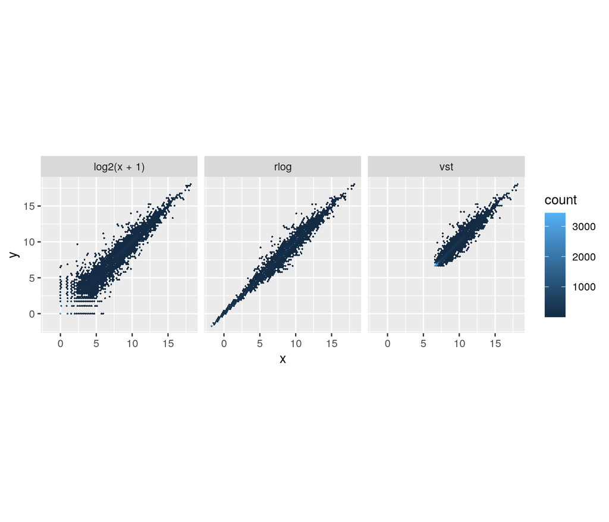

```r
library("dplyr")
library("ggplot2")

dds <- estimateSizeFactors(dds)

df <- bind_rows(
  as_data_frame(log2(counts(dds, normalized=TRUE)[, 1:2]+1)) %>%
         mutate(transformation = "log2(x + 1)"),
  as_data_frame(assay(vsd)[, 1:2]) %>% mutate(transformation = "vst"),
  as_data_frame(assay(rld)[, 1:2]) %>% mutate(transformation = "rlog"))
colnames(df)[1:2] <- c("x", "y")

ggplot(df, aes(x = x, y = y)) + geom_hex(bins = 80) +
  coord_fixed() + facet_grid( . ~ transformation)
```

. Shown are scatterplots using the log2 transform of normalized counts (left), using the VST (right), and using the rlog (middle). While the rlog is on roughly the same scale as the log2 counts, the VST has a upward shift for the smaller values. We can see how genes with low counts (bottom left-hand corner) seem to be excessively variable on the ordinary logarithmic scale, while the VST and rlog compress differences for the low count genes for which the data provide little information about differential expression.

#### 3.6.3 Samples distances

A useful first step in an RNA-seq analysis is often to assess overall similarity between samples: Which samples are similar to each other, which are different? Does this fit to the expectation from the experiment’s design?

```r
sampleDists <- dist(t(assay(vsd)))
sampleDists
```

```
##            SRR1039508 SRR1039509 SRR1039512 SRR1039513 SRR1039516 SRR1039517
## SRR1039509   44.08478
## SRR1039512   36.82952   51.50926
## SRR1039513   59.23174   43.11327   47.21641
## SRR1039516   41.08424   54.79377   40.18856   59.72262
## SRR1039517   59.08409   47.46042   54.13979   46.36635   44.74738
## SRR1039520   37.27578   54.00938   34.56797   55.44564   42.81024   58.22766
## SRR1039521   59.26716   42.84573   54.13120   35.24746   60.64298   47.80456
##            SRR1039520
## SRR1039509
## SRR1039512
## SRR1039513
## SRR1039516
## SRR1039517
## SRR1039520
## SRR1039521   48.24754
```

We visualize the distances in a heatmap in a figure below, using the function pheatmap from the pheatmap package.

In order to plot the sample distance matrix with the rows/columns arranged by the distances in our distance matrix, we manually provide sampleDists to the clustering_distance argument of the pheatmap function. Otherwise the pheatmap function would assume that the matrix contains the data values themselves, and would calculate distances between the rows/columns of the distance matrix, which is not desired.

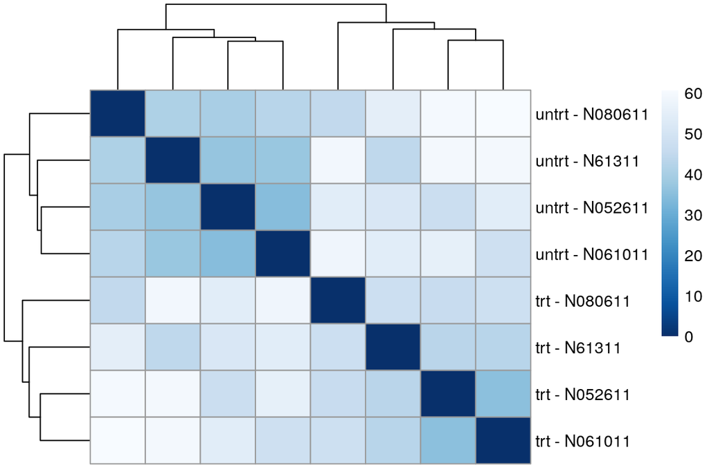

```r
library("pheatmap")
library("RColorBrewer")

sampleDistMatrix <- as.matrix( sampleDists )
rownames(sampleDistMatrix) <- paste( vsd$dex, vsd$cell, sep = " - " )
colnames(sampleDistMatrix) <- NULL
colors <- colorRampPalette( rev(brewer.pal(9, "Blues")) )(255)
pheatmap(sampleDistMatrix,
         clustering_distance_rows = sampleDists,
         clustering_distance_cols = sampleDists,
         col = colors)
```

Note that we have changed the row names of the distance matrix to contain treatment type and patient number instead of sample ID, so that we have all this information in view when looking at the heatmap.

#### 3.6.4 PCA plot

PCA plot using the VST data. Each unique combination of treatment and cell line is given its own color.

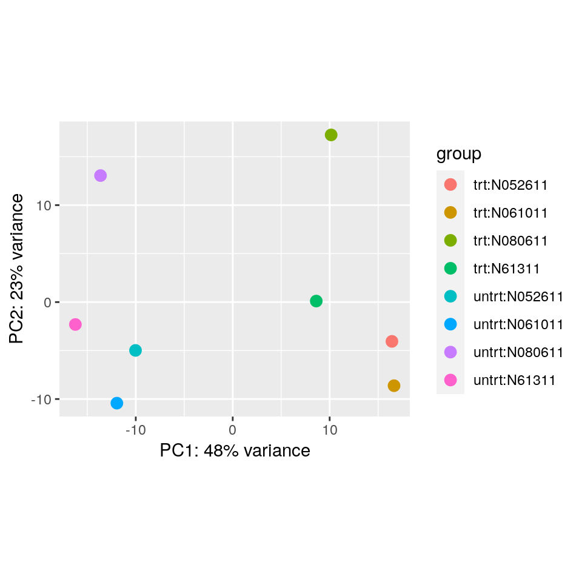

```r
plotPCA(vsd, intgroup = c("dex", "cell"))
```

#### 3.6.5 MDS plot

This is useful when we don’t have a matrix of data, but only a matrix of distances. Here we compute the MDS for the distances calculated from the VST data and plot these in a figure below.

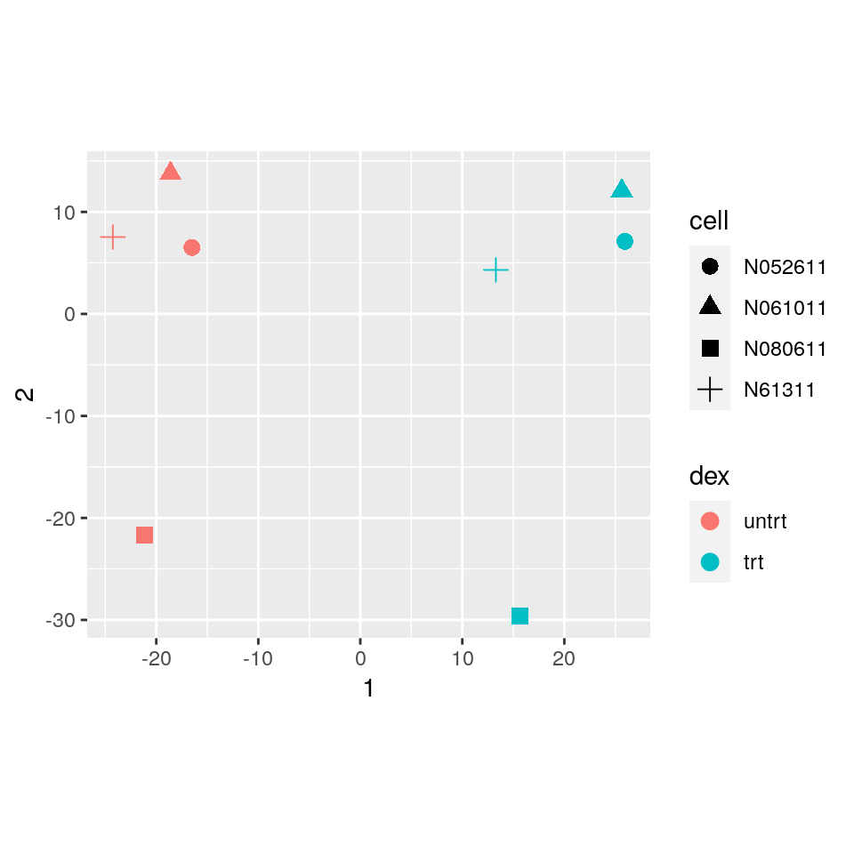

```r
mds <- as.data.frame(colData(vsd))  %>%
         cbind(cmdscale(sampleDistMatrix))
ggplot(mds, aes(x = `1`, y = `2`, color = dex, shape = cell)) +
  geom_point(size = 3) + coord_fixed()
```

### 3.7 Differential Expression Analysis

As we have already specified an experimental design when we created the `DESeqDataSet`, we can run the differential expression pipeline on the raw counts with a single call to the function DESeq:

```r
dds <- DESeq(dds, parallel =TRUE)
```

A `DESeqDataSet` is returned that contains all the fitted parameters within it, and the following section describes how to extract out results tables of interest from this object. \ Because dex is the last variable in the design, we could optionally leave off the contrast argument to extract the comparison of the two levels of dex.

```r
res <- results(dds, contrast=c("dex","trt","untrt"))
res
```

```
## log2 fold change (MLE): dex trt vs untrt
## Wald test p-value: dex trt vs untrt
## DataFrame with 29391 rows and 6 columns
##                   baseMean log2FoldChange     lfcSE       stat      pvalue
##                  <numeric>      <numeric> <numeric>  <numeric>   <numeric>
## ENSG00000000003 708.602170     -0.3812539  0.100654  -3.787751 0.000152017
## ENSG00000000419 520.297901      0.2068127  0.112219   1.842944 0.065337210
## ENSG00000000457 237.163037      0.0379206  0.143445   0.264357 0.791504963
## ENSG00000000460  57.932633     -0.0881677  0.287142  -0.307053 0.758803336
## ENSG00000000938   0.318098     -1.3782340  3.499875  -0.393795 0.693732273
## ...                    ...            ...       ...        ...         ...
## ENSG00000273485   1.286448      -0.127098  1.600421 -0.0794154    0.936702
## ENSG00000273486  15.452537      -0.150989  0.486499 -0.3103571    0.756289
## ENSG00000273487   8.163235       1.046408  0.698967  1.4970774    0.134373
## ENSG00000273488   8.584479       0.107831  0.638099  0.1689880    0.865806
## ENSG00000273489   0.275899       1.483726  3.513945  0.4222393    0.672850
##                       padj
##                  <numeric>
## ENSG00000000003 0.00128122
## ENSG00000000419 0.19620790
## ENSG00000000457 0.91119406
## ENSG00000000460 0.89463420
## ENSG00000000938         NA
## ...                    ...
## ENSG00000273485         NA
## ENSG00000273486   0.893661
## ENSG00000273487   0.329057
## ENSG00000273488   0.945183
## ENSG00000273489         NA
```

As is a DataFrame object, it carries metadata with information on the meaning of the columns:

```r
mcols(res, use.names = TRUE)
```

```
## DataFrame with 6 rows and 2 columns
##                        type                               description
##                 <character>                               <character>
## baseMean       intermediate mean of normalized counts for all samples
## log2FoldChange      results  log2 fold change (MLE): dex trt vs untrt
## lfcSE               results          standard error: dex trt vs untrt
## stat                results          Wald statistic: dex trt vs untrt
## pvalue              results       Wald test p-value: dex trt vs untrt
## padj                results                      BH adjusted p-values
```

We can also summarize the results with the following line of code:

```r
summary(res)
```

```
##
## out of 29391 with nonzero total read count
## adjusted p-value < 0.1
## LFC > 0 (up)       : 2607, 8.9%
## LFC < 0 (down)     : 2218, 7.5%
## outliers [1]       : 0, 0%
## low counts [2]     : 11397, 39%
## (mean count < 5)
## [1] see 'cooksCutoff' argument of ?results
## [2] see 'independentFiltering' argument of ?results
```

There are two ways to be more strict about which set of genes are considered significant:

If we lower the false discovery rate threshold:

```r
res.05 <- results(dds, alpha = 0.05)
table(res.05$padj < 0.05)
```

```
##
## FALSE  TRUE
## 12829  4026
```

If we want to raise the log2 fold change threshold:

```r
resLFC1 <- results(dds, lfcThreshold=1)
table(resLFC1$padj < 0.1)
```

```
##
## FALSE  TRUE
## 20034   240
```

Hence, if we consider a fraction of 10% false positives acceptable, we can consider all genes with an adjusted p value below 10% = 0.1 as significant. How many such genes are there?

```r
sum(res$padj < 0.1, na.rm=TRUE)
```

```
## [1] 4825
```

We subset the results table to these genes and then sort it by the log2 fold change estimate to get the significant genes with the strongest down-regulation:

```r
resSig <- subset(res, padj < 0.1)
head(resSig[ order(resSig$log2FoldChange), ])
```

```
## log2 fold change (MLE): dex trt vs untrt
## Wald test p-value: dex trt vs untrt
## DataFrame with 6 rows and 6 columns
##                  baseMean log2FoldChange     lfcSE      stat      pvalue
##                 <numeric>      <numeric> <numeric> <numeric>   <numeric>
## ENSG00000128285   6.62474       -5.32591  1.257816  -4.23425 2.29319e-05
## ENSG00000267339  26.23357       -4.61155  0.673094  -6.85127 7.31984e-12
## ENSG00000019186  14.08760       -4.32591  0.857768  -5.04321 4.57776e-07
## ENSG00000183454   5.80417       -4.26408  1.166877  -3.65426 2.57921e-04
## ENSG00000146006  46.80760       -4.21185  0.528852  -7.96414 1.66379e-15
## ENSG00000141469  53.43653       -4.12478  1.129798  -3.65091 2.61317e-04
##                        padj
##                   <numeric>
## ENSG00000128285 2.37557e-04
## ENSG00000267339 2.04842e-10
## ENSG00000019186 6.60463e-06
## ENSG00000183454 2.04722e-03
## ENSG00000146006 7.14248e-14
## ENSG00000141469 2.06961e-03
```

…and with the strongest up-regulation:

```r
head(resSig[ order(resSig$log2FoldChange, decreasing = TRUE), ])
```

```
## log2 fold change (MLE): dex trt vs untrt
## Wald test p-value: dex trt vs untrt
## DataFrame with 6 rows and 6 columns
##                  baseMean log2FoldChange     lfcSE      stat      pvalue
##                 <numeric>      <numeric> <numeric> <numeric>   <numeric>
## ENSG00000179593  67.24305        9.50597  1.054502   9.01465 1.97493e-19
## ENSG00000109906 385.07103        7.35263  0.536390  13.70761 9.14199e-43
## ENSG00000250978  56.31819        6.32738  0.677797   9.33521 1.00787e-20
## ENSG00000132518   5.65465        5.88511  1.324043   4.44480 8.79724e-06
## ENSG00000127954 286.38412        5.20716  0.493083  10.56042 4.54630e-26
## ENSG00000249364   8.83906        5.09811  1.159614   4.39638 1.10069e-05
##                        padj
##                   <numeric>
## ENSG00000179593 1.25130e-17
## ENSG00000109906 2.25344e-40
## ENSG00000250978 7.19669e-19
## ENSG00000132518 9.98722e-05
## ENSG00000127954 5.04976e-24
## ENSG00000249364 1.22259e-04
```

#### 3.7.1 Other comparisons

In general, the results for a comparison of any two levels of a variable can be extracted using the contrast argument to results. The user should specify three values: the name of the variable, the name of the level for the numerator, and the name of the level for the denominator. Here we extract results for the log2 of the fold change of one cell line over another:

```r
results(dds, contrast = c("cell", "N061011", "N61311"))
```

```
## log2 fold change (MLE): cell N061011 vs N61311
## Wald test p-value: cell N061011 vs N61311
## DataFrame with 29391 rows and 6 columns
##                   baseMean log2FoldChange     lfcSE       stat    pvalue
##                  <numeric>      <numeric> <numeric>  <numeric> <numeric>
## ENSG00000000003 708.602170      0.3063264  0.143531  2.1342194 0.0328248
## ENSG00000000419 520.297901     -0.0540467  0.159716 -0.3383924 0.7350675
## ENSG00000000457 237.163037      0.0163084  0.203026  0.0803267 0.9359774
## ENSG00000000460  57.932633      0.2791270  0.400667  0.6966552 0.4860186
## ENSG00000000938   0.318098      0.0000000  4.997580  0.0000000 1.0000000
## ...                    ...            ...       ...        ...       ...
## ENSG00000273485   1.286448     -2.3214126  2.352916 -0.9866108  0.323833
## ENSG00000273486  15.452537     -0.0727158  0.711891 -0.1021445  0.918642
## ENSG00000273487   8.163235     -0.0269347  1.005075 -0.0267987  0.978620
## ENSG00000273488   8.584479      1.0958476  0.898948  1.2190330  0.222832
## ENSG00000273489   0.275899      0.0000000  4.997580  0.0000000  1.000000
##                      padj
##                 <numeric>
## ENSG00000000003  0.214730
## ENSG00000000419  0.935494
## ENSG00000000457  0.989390
## ENSG00000000460  0.846164
## ENSG00000000938        NA
## ...                   ...
## ENSG00000273485        NA
## ENSG00000273486  0.985421
## ENSG00000273487        NA
## ENSG00000273488        NA
## ENSG00000273489        NA
```

If results for an interaction term are desired, the name argument of results should be used.

### 3.8 Plotting results

#### 3.8.1 Counts plot

A quick way to visualize the counts for a particular gene is to use the plotCounts function that takes as arguments the `DESeqDataSet`, a gene name, and the group over which to plot the counts

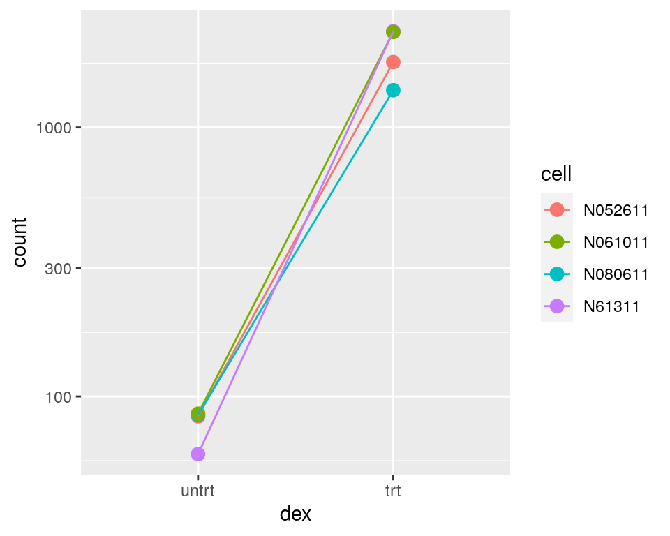

```r
topGene <- rownames(res)[which.min(res$padj)]

library("ggbeeswarm")

geneCounts <- plotCounts(dds, gene = topGene, intgroup = c("dex","cell"),
                         returnData = TRUE)
ggplot(geneCounts, aes(x = dex, y = count, color = cell, group = cell)) +
  scale_y_log10() + geom_point(size = 3) + geom_line()
```

#### 3.8.2 MA-Plot

An MA-plot (Dudoit et al. 2002) provides a useful overview for the distribution of the estimated coefficients in the model, e.g. the comparisons of interest, across all genes. On the y-axis, the “M” stands for “minus” – subtraction of log values is equivalent to the log of the ratio – and on the x-axis, the “A” stands for “average”.

Before making the MA-plot, we use the function to shrink the log2 fold changes for the comparison of dex treated vs untreated samples. There are three types of shrinkage estimators in DESeq2, which are covered in the DESeq2 vignette. Here we specify the apeglm method for shrinking coefficients, which is good for shrinking the noisy LFC estimates while giving low bias LFC estimates for true large differences (Zhu, Ibrahim, and Love 2018). To use apeglm we specify a coefficient from the model to shrink, either by name or number as the coefficient appears in resultsNames(dds).

```r
library("apeglm")
resultsNames(dds)
```

```
## [1] "Intercept"               "cell_N061011_vs_N052611"
## [3] "cell_N080611_vs_N052611" "cell_N61311_vs_N052611"
## [5] "dex_trt_vs_untrt"
```

```r
res <- lfcShrink(dds, coef="dex_trt_vs_untrt", type="apeglm")
```

```
## using 'apeglm' for LFC shrinkage. If used in published research, please cite:
##     Zhu, A., Ibrahim, J.G., Love, M.I. (2018) Heavy-tailed prior distributions for
##     sequence count data: removing the noise and preserving large differences.
##     Bioinformatics. https://doi.org/10.1093/bioinformatics/bty895
```

[figure not shown]

```r
plotMA(res, ylim = c(-5, 5))
```

We can label individual points on the MA-plot as well. Here we use the with R function to plot a circle and text for a selected row of the results object:

[figure not shown]

```r
plotMA(res, ylim = c(-5,5))
topGene <- rownames(res)[which.min(res$padj)]
with(res[topGene, ], {
  points(baseMean, log2FoldChange, col="dodgerblue", cex=2, lwd=2)
  text(baseMean, log2FoldChange, topGene, pos=2, col="dodgerblue")
})
```

#### 3.8.3 Gene clustering

One usually would only cluster a subset of the most highly variable genes. Here, for demonstration, let us select the 20 genes with the highest variance across samples. We will work with the VST data.

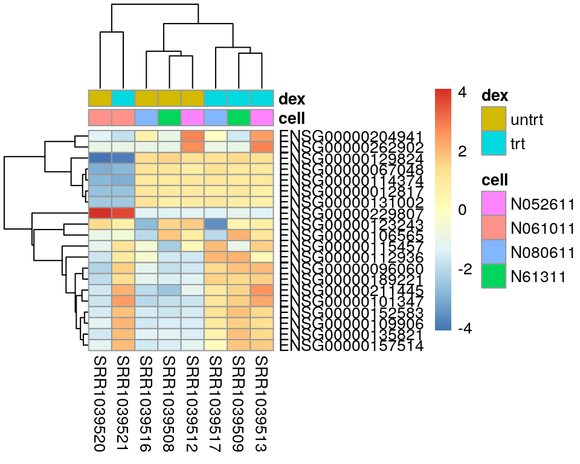

```r
library("genefilter")
topVarGenes <- head(order(rowVars(assay(vsd)), decreasing = TRUE), 20)

mat  <- assay(vsd)[topVarGenes, ]
mat  <- mat - rowMeans(mat)
anno <- as.data.frame(colData(vsd)[, c("cell","dex")])
pheatmap(mat, annotation_col = anno)
```

#### 3.8.4 Ploting fold changes in genomic space

NOTE: This section can only be performed if we have information on the position of reads in the genome. That is if we have created our `DESeqDataSet` from a `SummarizedExperiment` object and we have used the `summarizeOverlaps` function to count the reads.

In that case our `DESeqDataSet` object is built on top of ready-to-use Bioconductor objects specifying the genomic coordinates of the genes. We can therefore easily plot our differential expression results in genomic space. While the results function by default returns a `DataFrame`, using the format argument, we can ask for `GRanges` or `GRangesList` output. `lfcShrink` does not yet have the option to output `GRanges`, so we add the column of shrunken coefficients manually.

```r
resGR <- results(dds, name="dex_trt_vs_untrt", format="GRanges")
```

```
## rowRanges is GRangesList, performing unlist(range(x)) on the rowRanges
```

```r
resGR$log2FoldChange <- res$log2FoldChange
resGR
```

```
## GRanges object with 29391 ranges and 6 metadata columns:
##                   seqnames              ranges strand |   baseMean
##                      <Rle>           <IRanges>  <Rle> |  <numeric>
##   ENSG00000000003        X   99883667-99894988      - | 708.602170
##   ENSG00000000419       20   49551404-49575092      - | 520.297901
##   ENSG00000000457        1 169818772-169863408      - | 237.163037
##   ENSG00000000460        1 169631245-169823221      + |  57.932633
##   ENSG00000000938        1   27938575-27961788      - |   0.318098
##               ...      ...                 ...    ... .        ...
##   ENSG00000273485       10 105209953-105210609      + |   1.286448
##   ENSG00000273486        3 136556180-136557863      - |  15.452537
##   ENSG00000273487        1   92654794-92656264      + |   8.163235
##   ENSG00000273488        3 100080031-100080481      + |   8.584479
##   ENSG00000273489        7 131178723-131182453      - |   0.275899
##                   log2FoldChange     lfcSE       stat      pvalue       padj
##                        <numeric> <numeric>  <numeric>   <numeric>  <numeric>
##   ENSG00000000003     -0.3584541  0.100654  -3.787751 0.000152017 0.00128122
##   ENSG00000000419      0.1860726  0.112219   1.842944 0.065337210 0.19620790
##   ENSG00000000457      0.0313468  0.143445   0.264357 0.791504963 0.91119406
##   ENSG00000000460     -0.0472622  0.287142  -0.307053 0.758803336 0.89463420
##   ENSG00000000938     -0.0123431  3.499875  -0.393795 0.693732273         NA
##               ...            ...       ...        ...         ...        ...
##   ENSG00000273485    -0.00445615  1.600421 -0.0794154    0.936702         NA
##   ENSG00000273486    -0.04309283  0.486499 -0.3103571    0.756289   0.893661
##   ENSG00000273487     0.19116398  0.698967  1.4970774    0.134373   0.329057
##   ENSG00000273488     0.02194011  0.638099  0.1689880    0.865806   0.945183
##   ENSG00000273489     0.01219803  3.513945  0.4222393    0.672850         NA
##   -------
##   seqinfo: 722 sequences (1 circular) from an unspecified genome
```

We need to add the symbol again for labeling the genes on the plot:

```r
library("org.Hs.eg.db")
resGR$symbol <- mapIds(org.Hs.eg.db, names(resGR), "SYMBOL", "ENSEMBL")
```

We will use the Gviz package for plotting the GRanges and associated metadata: the log fold changes due to dexamethasone treatment. The following code chunk specifies a window of 1 million base pairs upstream and downstream from the gene with the smallest p value. We create a subset of our full results, for genes within the window. We add the gene symbol as a name if the symbol exists and is not duplicated in our subset.

```r
library("Gviz")

window <- resGR[topGene] + 1e6
strand(window) <- "*"
resGRsub <- resGR[resGR %over% window]
naOrDup <- is.na(resGRsub$symbol) | duplicated(resGRsub$symbol)
resGRsub$group <- ifelse(naOrDup, names(resGRsub), resGRsub$symbol)
```

We create a vector specifying if the genes in this subset had a low value of padj.

```r
status <- factor(ifelse(resGRsub$padj < 0.1 & !is.na(resGRsub$padj), "sig", "notsig"))
```

We can then plot the results using Gviz functions (figure below). We create an axis track specifying our location in the genome, a track that will show the genes and their names, colored by significance, and a data track that will draw vertical bars showing the moderated log fold change produced by DESeq2, which we know are only large when the effect is well supported by the information in the counts.

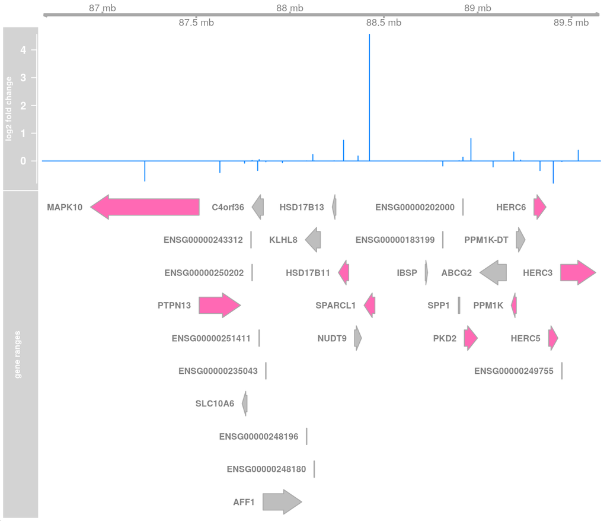

```r
options(ucscChromosomeNames = FALSE)
g <- GenomeAxisTrack()
a <- AnnotationTrack(resGRsub, name = "gene ranges", feature = status)
d <- DataTrack(resGRsub, data = "log2FoldChange", baseline = 0,
               type = "h", name = "log2 fold change", strand = "+")
plotTracks(list(g, d, a), groupAnnotation = "group",
           notsig = "grey", sig = "hotpink")
```

### 3.9 Annotating and exporting results

Our result table so far only contains the Ensembl gene IDs, but alternative gene names may be more informative for interpretation. Bioconductor’s annotation packages help with mapping various ID schemes to each other:

```r
library("AnnotationDbi")
columns(org.Hs.eg.db)
```

```
##  [1] "ACCNUM"       "ALIAS"        "ENSEMBL"      "ENSEMBLPROT"  "ENSEMBLTRANS"
##  [6] "ENTREZID"     "ENZYME"       "EVIDENCE"     "EVIDENCEALL"  "GENENAME"
## [11] "GO"           "GOALL"        "IPI"          "MAP"          "OMIM"
## [16] "ONTOLOGY"     "ONTOLOGYALL"  "PATH"         "PFAM"         "PMID"
## [21] "PROSITE"      "REFSEQ"       "SYMBOL"       "UCSCKG"       "UNIGENE"
## [26] "UNIPROT"
```

We can use the mapIds function to add individual columns to our results table. We provide the row names of our results table as a key, and specify that keytype=ENSEMBL. The column argument tells the mapIds function which information we want, and the multiVals argument tells the function what to do if there are multiple possible values for a single input value. Here we ask to just give us back the first one that occurs in the database. To add the gene symbol and Entrez ID, we call mapIds twice.

```r
res$symbol <- mapIds(org.Hs.eg.db,
                     keys=row.names(res),
                     column="SYMBOL",
                     keytype="ENSEMBL",
                     multiVals="first")
res$entrez <- mapIds(org.Hs.eg.db,
                     keys=row.names(res),
                     column="ENTREZID",
                     keytype="ENSEMBL",
                     multiVals="first")
resOrdered <- res[order(res$pvalue),]
head(resOrdered)
```

```
## log2 fold change (MAP): dex trt vs untrt
## Wald test p-value: dex trt vs untrt
## DataFrame with 6 rows and 7 columns
##                  baseMean log2FoldChange     lfcSE       pvalue         padj
##                 <numeric>      <numeric> <numeric>    <numeric>    <numeric>
## ENSG00000152583   997.440        4.56335  0.185620 2.22232e-136 3.99884e-132
## ENSG00000165995   495.093        3.28035  0.133331 7.83976e-135 7.05343e-131
## ENSG00000120129  3409.029        2.93799  0.122028 3.66732e-130 2.19966e-126
## ENSG00000101347 12703.387        3.75352  0.157054 9.58234e-130 4.31061e-126
## ENSG00000189221  2341.767        3.34219  0.143094 1.09937e-123 3.95642e-120
## ENSG00000211445 12285.615        3.71695  0.167890 4.61814e-112 1.38498e-108
##                      symbol      entrez
##                 <character> <character>
## ENSG00000152583     SPARCL1        8404
## ENSG00000165995      CACNB2         783
## ENSG00000120129       DUSP1        1843
## ENSG00000101347      SAMHD1       25939
## ENSG00000189221        MAOA        4128
## ENSG00000211445        GPX3        2878
```

#### 3.9.1 Exporting results

The results of the analysis can be written to a CSV file:

```r
resOrderedDF <- as.data.frame(resOrdered)
write.csv(resOrderedDF, file = "results2.csv")
```

Alternatively a searchable, sortable html table can be created using the `ReportingTools` package:

```r
library("ReportingTools")
htmlRep <- HTMLReport(shortName="report", title="My report",
                      reportDirectory=".")
publish(resOrderedDF, htmlRep)
url <- finish(htmlRep)
browseURL(url)
```

### 4.0 Removing hidden batch effects

We can use statistical methods designed for RNA-seq from the sva package (Leek 2014) or the RUVSeq package (Risso et al. 2014) in Bioconductor to detect such groupings of the samples, and then we can add these to the `DESeqDataSet` design, in order to account for them.

The SVA package uses the term surrogate variables for the estimated variables that we want to account for in our analysis, while the RUV package uses the terms factors of unwanted variation with the acronym “Remove Unwanted Variation” explaining the package title. We first use SVA to find hidden batch effects and then RUV following.

#### 4.1 Using SVA with DESeq2

Below we obtain a matrix of normalized counts for which the average count across samples is larger than 1. As we described above, we are trying to recover any hidden batch effects, supposing that we do not know the cell line information. So we use a full model matrix with the dex variable, and a reduced, or null, model matrix with only an intercept term. Finally we specify that we want to estimate 2 surrogate variables. For more information read the manual page for the svaseq function.

```r
library("sva")

dat  <- counts(dds, normalized = TRUE)
idx  <- rowMeans(dat) > 1
dat  <- dat[idx, ]
mod  <- model.matrix(~ dex, colData(dds))
mod0 <- model.matrix(~   1, colData(dds))
svseq <- svaseq(dat, mod, mod0, n.sv = 2)
```

```
## Number of significant surrogate variables is:  2
## Iteration (out of 5 ):1  2  3  4  5
```

```r
svseq$sv
```

```
##            [,1]        [,2]
## [1,]  0.2481108 -0.52600157
## [2,]  0.2629867 -0.58115433
## [3,]  0.1502704  0.27428267
## [4,]  0.2023800  0.38419545
## [5,] -0.6086586 -0.07854931
## [6,] -0.6101210 -0.02923693
## [7,]  0.1788509  0.25708985
## [8,]  0.1761807  0.29937417
```

Because we actually do know the cell lines, we can see how well the SVA method did at recovering these variables (figure below).

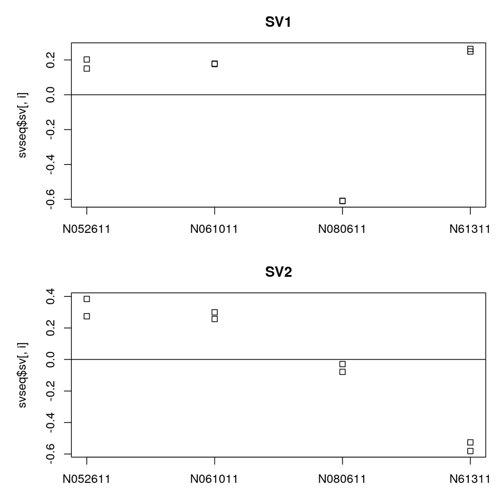

```r
par(mfrow = c(2, 1), mar = c(3,5,3,1))
for (i in 1:2) {
  stripchart(svseq$sv[, i] ~ dds$cell, vertical = TRUE, main = paste0("SV", i))
  abline(h = 0)
 }
```

Here, we know the hidden source of variation (cell line), and therefore can see how the SVA procedure is able to identify a source of variation which is correlated with cell line.

Finally, in order to use SVA to remove any effect on the counts from our surrogate variables, we simply add these two surrogate variables as columns to the `DESeqDataSet` and then add them to the design:

```r
ddssva <- dds
ddssva$SV1 <- svseq$sv[,1]
ddssva$SV2 <- svseq$sv[,2]
design(ddssva) <- ~ SV1 + SV2 + dex
```

We could then produce results controlling for surrogate variables by running DESeq with the new design.

#### 4.2 Using RUB with DESeq2

We can use the RUVg function to estimate factors of unwanted variation, analogous to SVA’s surrogate variables. A difference compared to the SVA procedure above, is that we first would run DESeq and results to obtain the p-values for the analysis without knowing about the batches, e.g. just ~ dex. Supposing that we have this results table res, we then pull out a set of empirical control genes by looking at the genes that do not have a small p-value.

```r
library("RUVSeq")

set <- newSeqExpressionSet(counts(dds))
idx  <- rowSums(counts(set) > 5) >= 2
set  <- set[idx, ]
set <- betweenLaneNormalization(set, which="upper")
not.sig <- rownames(res)[which(res$pvalue > .1)]
empirical <- rownames(set)[ rownames(set) %in% not.sig ]
set <- RUVg(set, empirical, k=2)
pData(set)
```

```
##                    W_1         W_2
## SRR1039508 -0.17841946  0.49379636
## SRR1039509 -0.20749027  0.61226276
## SRR1039512 -0.05113443 -0.07266363
## SRR1039513 -0.14974859 -0.07839422
## SRR1039516  0.58209686 -0.05446432
## SRR1039517  0.61285776 -0.04648514
## SRR1039520 -0.28519844 -0.42231712
## SRR1039521 -0.32296344 -0.43173467
```

We can plot the factors estimated by RUV:

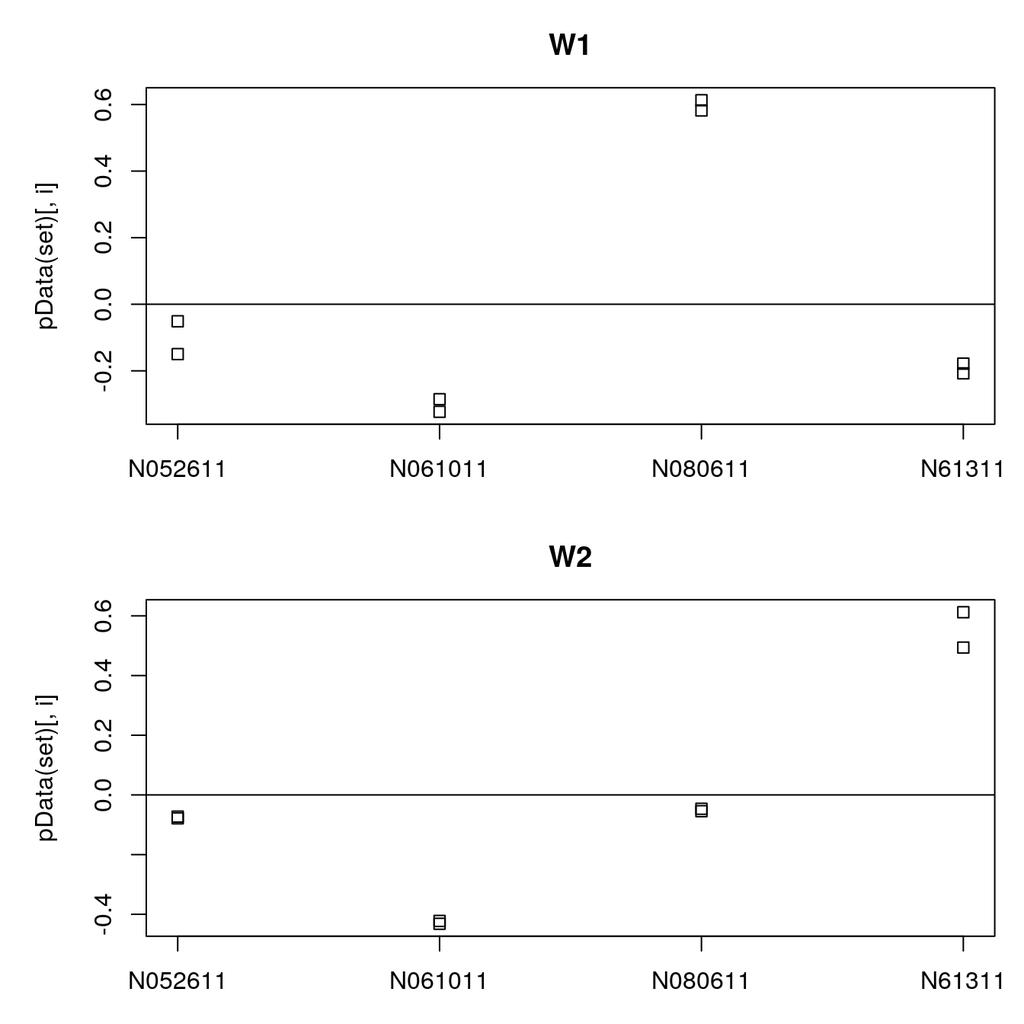

```r
par(mfrow = c(2, 1), mar = c(3,5,3,1))
for (i in 1:2) {
  stripchart(pData(set)[, i] ~ dds$cell, vertical = TRUE, main = paste0("W", i))
  abline(h = 0)
 }
```

As before, if we wanted to control for these factors, we would simply add them to the `DESeqDataSet` and to the design:

```r
ddsruv <- dds
ddsruv$W1 <- set$W_1
ddsruv$W2 <- set$W_2
design(ddsruv) <- ~ W1 + W2 + dex
```

We would then run DESeq with the new design to re-estimate the parameters and results.